# An exploration of the impact of keyboard type and typing performance

## Keyboard issue, not a skill issue

Exploring the impact of the type of keyboard used on typing performance, through 15 second typing tests on [monkeytype](https://www.monkeytype.com).

## First, understanding typing performance

Data was collected over the course of a month and a half, resulting in 40 observations. Every time I completed a 15 second typing test on monkeytype, I would fill out the form, entering the keyboard used, the words per minute (wpm) achieved, and the accuracy.

Looking at the data collected, there is a pretty clear trend between wpm and accuracy. In general, higher accuracy would result in higher wpm, which makes sense as it is the actual wpm as opposed to the raw wpm, meaning lower accuracy negatively affects the wpm. Typing performance for me relates to both the speed and accuracy of your typing so the data field wpm represents this perfectly.

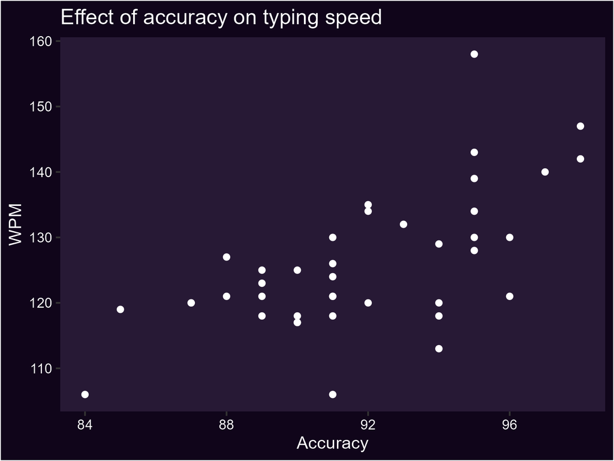

A scatter plot titled ‘Effect of accuracy on typing speed’ with accuracy on the x axis and wpm on the y axis

## Just cope and actually just skill issue?

Observing the collected data, it suggests that there isn’t a noticeably clear difference in typing performance with the type of keyboard used, all the types roaming around a low to mid 120wpm mean.

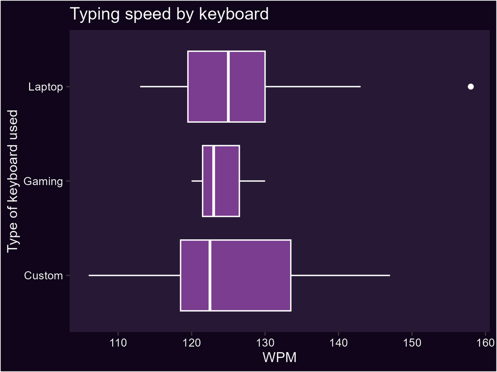

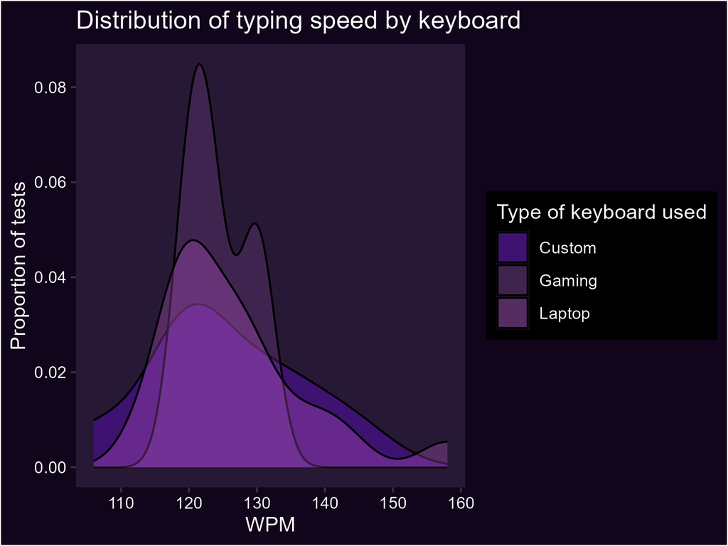

## Consistency is king

While peaks and all are cool, what really matters is the consistency of achieving a ‘good enough’ wpm, as in general for me, consistency is more valuable than top speed outside of trying for a personal best. When considering this, all three types of keyboards show similar results, all getting similar number of tests that achieved higher than 120wpm relative to the total number of tests done with that keyboard. This, again, emphasises how the keyboard used is not a major factor, and the fact that I just have a skill issue.

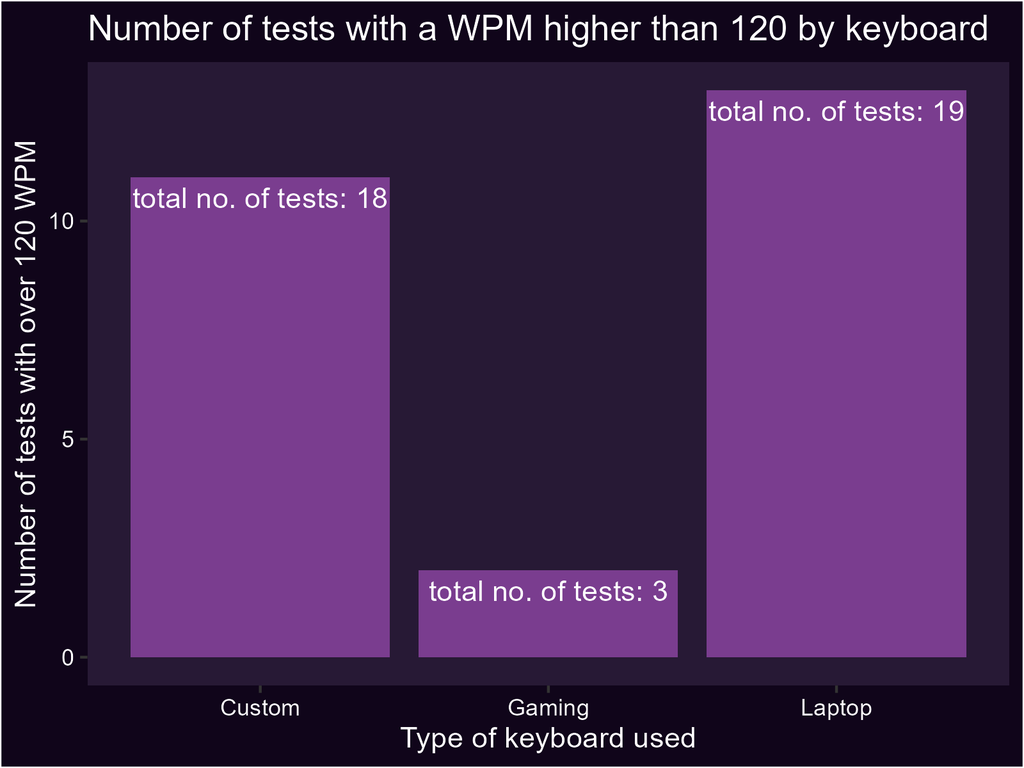

A bar chart showing the count of typing tests that achieved greater than 120wpm, separated by the keyboard used

## Or maybe the time of day?

Comparing the wpm achieved with the time of the day, there really seems to be no correlation, meaning my typing performance is largely unaffected by the time of the day, Then again, I never did any early in the morning right after waking up so there may be interesting observations to be made there.

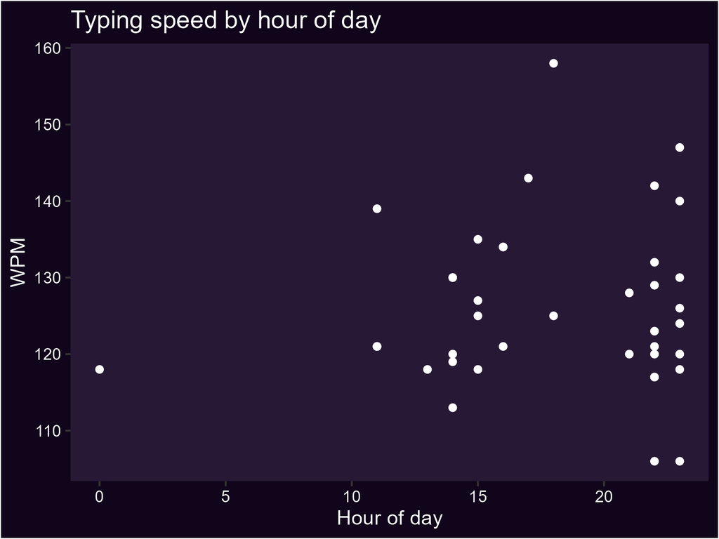

A scatter plot titled typing speed by hour, where there is no clear correlation between the y (wpm) and the x (hour of the day)

# Conclusion

All in all, it seems clear to me that it’s just a skill issue and the type of keyboard I use when typing doesn’t have any significant impact on my typing performance. But considering the amount of money I’ve spent on my custom keyboards, I think even if there was a significant decrease in typing performance based on it, I would still use them primarily.